# Lab 11: Regression diagnostics

2015-07-128

** Inspiration for this lab comes from the work of Jonathan Tannen

## "Advances in Development Reverse Fertility Declines"

Today we will be working on the recent, important paper in Nature by Mikko Myrskyla, Hans-Peter Kohler & Francesco C. Billari (2009).

This paper examined the relationship between the Human Development Index (HDI) and the Total Fertility Rate (TFR) in 143 countries.

- Download: http://www.nature.com/nature/journal/v460/n7256/extref/nature08230-s2.zip
- Open a new R Script, set it up, and read.csv the data.
- Drop all but the HDI and TFR for 1975 and 2005 (use dplyr)

```r
library(dplyr)
library(ggplot2)
data <- read.csv("data/nature08230-s2.csv")
data <- select(data, country, HDI.1975, TFR.1975, HDI.2005, TFR.2005)
```

## Digging In

Explore the dataset. Make some plots. Do some calculations. What do you see?

## Using lm()

- Use "lm(y ~ x)" to regress TFR on HDI for 1975.
- Use "lm(y ~ x)" as lfit, and use "summary(lfit)."
- What is the observed relationship?
- Use the coefficient in a sentence.
- Interpret the constant.

## An lm() Object

- lm() doesn't just spit out values, it stores anything you could ever need
- Use "str(lift)" to look at the structure of lfit. What's inside?
- Can you print the coefficients?
- Add the regression line to your scatter plot.
- Can you print the true TFR and the predicted TFR side by side? (you will need to address the missing data issue)
- Bonus: Instead of summary(lfit), try installing and using the "broom" package. Which one do you like better? (see ??broom for more information)

## Residuals

[Fortify and ggplot2](http://docs.ggplot2.org/0.9.3.1/fortify.lm.html)

- See ?fortify.lm
- Make a new scatter plot of the residuals versus the fitted values.

[Learn more about residuals](http://blog.minitab.com/blog/adventures-in-statistics/why-you-need-to-check-your-residual-plots-for-regression-analysis)

## Comparing 1975 to 2005

- Return to the original HDI-TFR scatter plot.
- Add the 2005 data to your scatter plot in red.
- Perform the HDI on TFR regression for 2005 data.
- Add the new regression line to your plot.
- Did the relationship change from 1975 to 2005?
- Bonus: Make some aesthetic improvements to the graph
- Bonus: Make a new scatter plot of the residuals versus the fitted values for the 2005 data.

## The Killer Graph

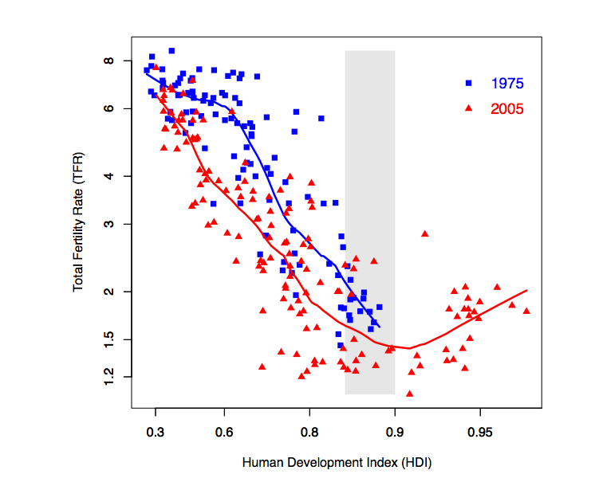

## The Killer Graph

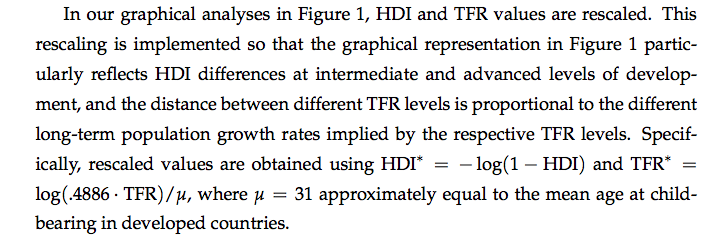

## What Makes a Killer Graph?